# Affymetrix-Analyses in Qing et al. 2022, npj Breast Cancer, PMID: 36344517

# Analyses of Affymetrix cohort starting with 2007 samples

## Preparations

Set up libraries and themes:

```r
datapath <- "./data/"

library(data.table)
library(dplyr)
```

```r
library(ggplot2)
th = theme_bw() + theme(
  panel.border = element_blank(),
  panel.grid.major = element_blank(),
  panel.grid.minor = element_blank(),
  axis.line = element_line(colour = "black")
) + theme(
  legend.position = 'none',
  axis.text.x = element_text(colour = "black", size = 12),
  axis.text.y = element_text(
    colour = "black",
    size = 12,
    hjust = 0.95
  ),
  axis.ticks = element_blank(),
  plot.title = element_text(hjust = 0.5, face = "bold"),
  axis.title = element_text(size = 12, face = "bold")
) + theme(
  strip.placement = "outside",
  plot.title = element_text(hjust = 0.5),
  strip.text.x = element_text(size = 12),
  strip.text.y = element_text(angle = 0, size = 10, face = "italic"),
  panel.spacing = unit(0.1, "lines"),
  strip.background = element_rect(fill = "#EEEEEE", color = "#FFFFFF")
)
```

Load signatures:

```r
signature <- read.delim(paste0(datapath,"signatures.txt"), h=T)
sig_lists=list()
for(i in 1:dim(signature)[1]){
  sig_lists[as.character(signature$Short[i])]=list(as.character(strsplit(as.character(signature$Affymetrix.probesets[i]),split=",")[[1]]))
}
```

## Import Affymetrix microarray expression data

Import of MAS5 data from table (chip data complete): 22283 Affy probes in rows and 2007 columns with samples (header: combi_id)

```r
cd.compl <- read.delim(paste0(datapath,"n2007_MAS5.txt"),h=T)
# use first column with Affy IDs as rownames
rownames(cd.compl) <- cd.compl[,1]
cd.compl <- cd.compl[,-1]  # then delete first column
# Import of clinical info as transposed header
t.header <- read.delim(paste0(datapath,"n2007_SampleInfo.txt"),h=T)
# Add "X" to rownames of t.header
rownames(t.header) <- paste("X",t.header$combi_id, sep="")
n.probes=nrow(cd.compl)
tdsn=as.numeric(t.header$datas_new09)   # transposed dataset allocation vector, numeric
tcdm=t(cd.compl)   # transposed chip data matrix
rm(cd.compl)
```

## Select most comparable samples from n=2007 breast cancers with MAS5 Affymetrix data

Calculate within each dataset the means of each probeset, the global meand and standard deviation:

```r
ds.mean=by(tcdm, tdsn, colMeans)  # means of each probeset within individual datasets,
tcdm.mean=apply(tcdm,2,mean) #   list of 22283 global means
tcdm.stdev=apply(tcdm,2, sd)   # the same for the StdDev
```

Calculate the comparability metrics (C) for the datasets (sum of squared differences of dataset-mean from total-mean for all probesets):

```r
n.datas=length(ds.mean)   # number of datasets
nrm.diff.to.mean= matrix(0,nrow=n.probes,ncol=n.datas) # matrix of NORMALIZED diff from mean

for (probes in 1:n.probes)   # loop for all probesets
{
    for (i in 1:n.datas)
    # calculate for each dataset diff from global-mean of all datasets
    # normalize by dividing through StdDev
    # and save in matrix "nrm.diff.to.mean"
  {
    nrm.diff.to.mean[probes,i]=(ds.mean[[i]][probes]- tcdm.mean[probes]) / tcdm.stdev[probes]
  }
}

# calculate squares of differences
squ.nrm.diff= nrm.diff.to.mean^2
# sum of squared differences by column
sum.squ.nrm.diff=apply(na.omit(squ.nrm.diff),2,sum)
# summarize results
comparab=data.frame(sort(unique(tdsn)),sum.squ.nrm.diff)
names(comparab)=c("dataset","sum.squ.nrm.diff")
# these vectors are still sorted by numeric dataset tdsn !
sort.comparab=comparab[order(comparab$sum.squ.nrm.diff),]

# integrate normalized comparab data in sample info in t.header
for (i in 1:nrow(tcdm))
{t.header$comparab_nrm[i]= comparab$sum.squ.nrm.diff[comparab$dataset==tdsn[i]]}
# remove temporary variables:
rm(nrm.diff.to.mean, ds.mean,tcdm.mean, tcdm.stdev, squ.nrm.diff, sum.squ.nrm.diff)
```

# **COHORT-A**

## SELECT “COHORT A” of breast cancer datasets with comparability metric <5000

```r
# Select a subset of comparab by defining criteria:
compar.subset= subset(comparab, subset= sum.squ.nrm.diff < 5000)
# vector of corresponding datasets:
datas.subset=compar.subset$dataset
# generate logical vector FALSE/TRUE for the complete dataset of 2007 BC:
subset.index.vector=(tdsn %in% datas.subset)
# query selected samples from transposed chipdata matrix and t.header:
tcdm.find=tcdm[subset.index.vector , ]
t.header.find= t.header[subset.index.vector,]
# remove temporary variables:
rm(compar.subset, datas.subset, subset.index.vector)
```

## Determine RecurrenceScore of Cohort-A

We apply the oncotypedx function from the genefu package on the finding cohort of 1170 samples:

```r
library(genefu)
```

```r
rs.find <- oncotypedx(data= tcdm.find, annot= U133A_Affy_Entrez, do.mapping=FALSE, verbose=TRUE)
t.header.find <- cbind(t.header.find,rs.find$score)
```

Exclude those 20% of samples with highest oncotypedx scoring:

```r
# Select a subset of datasets with rs.find$score < 80%-Quantile
t.header.find.lowint <- subset(t.header.find, subset= rs.find$score < as.numeric(quantile(rs.find$score, probs=0.8)))
tcdm.find.lowint <- tcdm.find[rownames(tcdm.find) %in% rownames(t.header.find.lowint),]
dim(tcdm.find.lowint)
```

```
## [1]   936 22283
```

## COHORT-A Compare expression signatures between young and old patients

A label “cohort” is defined which can be used to tag output files

```r
cohort <- "Cohort-A_"
```

Log2-expression data matrix ==> mat; Clinical data ==> clin

```r
clin <- t.header.find.lowint
clin$Xcombi_id <- rownames(clin)
mat <- log2(t(tcdm.find.lowint))
```

## Distribution of ESR1 and MKI67 mRNA expression in ER+/HER2- breast cancers in three cohorts. (Suppl.Fig.1, Cohort-A)

Define three age groups and plot data:

```r
clin$type <- "intermediate"
clin$type[clin$age>=55] <- "old"
clin$type[clin$age<=50] <- "young"
clin$type <- factor(clin$type, levels = c("young", "intermediate", "old"))
plotdat <- data.frame(mat["205225_at",], clin$type)
colnames(plotdat) <- c("ESR1_205225_at", "Age_group")
plotdat$MKI67_mean <- apply(mat[which(rownames(mat)%in%sig_lists$MKI67),],2,mean)
```

Plot distribution of ESR1 expression according to age group:

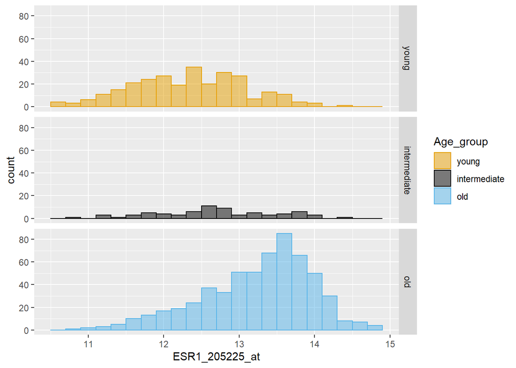

```r
p <- ggplot(plotdat, aes(x = ESR1_205225_at, fill = Age_group, color = Age_group)) +
  geom_histogram(binwidth=0.2,  alpha=0.5, position="identity")
plot(p + scale_color_manual(values=c("#E69F00", "black", "#56B4E9"))+
  scale_fill_manual(values=c("#E69F00", "black", "#56B4E9"))+
  facet_grid(Age_group ~ .))
```

Plot distribution of MKI67 expression according to age group:

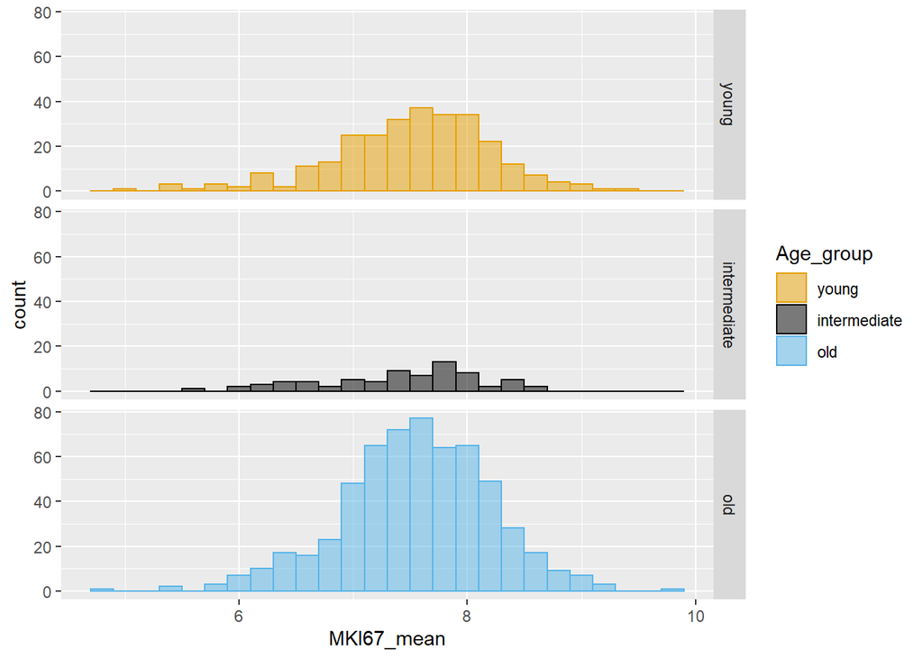

```r
p <- ggplot(plotdat, aes(x = MKI67_mean, fill = Age_group, color = Age_group)) +
  geom_histogram(binwidth=0.2,  alpha=0.5, position="identity")
plot(p + scale_color_manual(values=c("#E69F00", "black", "#56B4E9"))+
  scale_fill_manual(values=c("#E69F00", "black", "#56B4E9"))+
  facet_grid(Age_group ~ .))
```

## Compare young (<=50yr) vs. old (>=55) in Cohort-A:

Select sample subgroups (>=55 yr vs. <=50 yr):

```r
### Generate "type" as factor age>=55:old or age<=50:young
clin$type <- NA
clin$type[clin$age>=55] <- "old"
clin$type[clin$age<=50] <- "young"
clin$type <- as.factor(clin$type)

### EXCLUDE SAMPLES with age between 51 and 54 years  (clin$type=NA)
clin <- clin[!is.na(clin$type),]
mat <- mat[,colnames(mat) %in% rownames(clin)]
```

Estimate the expression signatures by taking the average expression of all member genes in a signature for each individual patient.

```r
mat_signature=NULL
for(sig in names(sig_lists)){
  score=apply(mat[which(rownames(mat)%in%sig_lists[[sig]]),],2,mean)
  mat_signature=rbind(mat_signature,score)
}
rownames(mat_signature)=names(sig_lists)
# Add ESR1 as single gene to the mat_signature
ESR1 <- mat["205225_at",]
mat_signature <- rbind(mat_signature, ESR1)
mat_signature_zscore=as.data.frame(cbind(Xcombi_id=colnames(mat_signature),apply(mat_signature,1,function(x)(x-mean(x))/sd(x))))
finalMat=merge(clin, mat_signature_zscore, by="Xcombi_id")
```

### Scatter plots for correlation between signatures in Suppl.Fig.4, Cohort-A:

```r
library(psych)
```

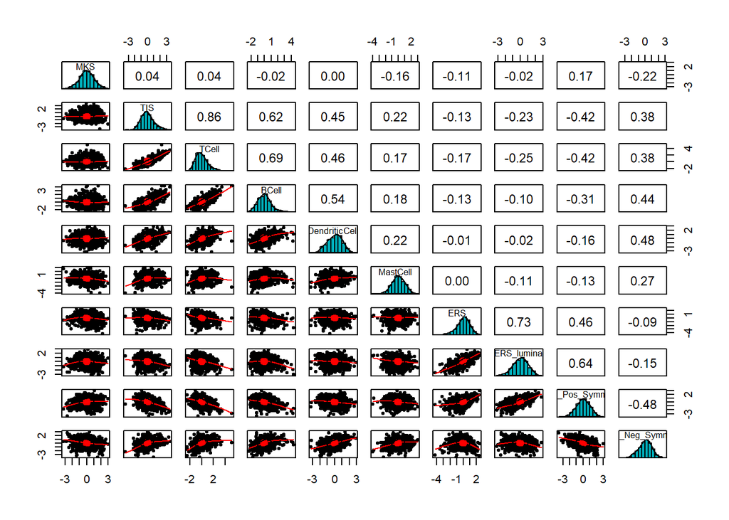

```r
pairs.panels(finalMat%>%dplyr::select("MKS","TIS","TCell","BCell","DendriticCell","MastCell","ERS","ERS_luminal","ERS_Pos_Symmans","ERS_Neg_Symmans")%>%mutate_all(~as.numeric(as.matrix(.))),
             method = "pearson", # correlation method
             hist.col = "#00AFBB",
             density = TRUE,  # show density plots
             ellipses = TRUE, # show correlation ellipses
             cex=1
)
```

### Comparison of signatures in young vs old by Mann-Whitney test (Table 2, Cohort-A)

```r
ttMW=NULL
for(s in rownames(mat_signature)){
  submat=finalMat[,c("type",s)]
  submat[,s]=as.numeric(as.matrix(submat[,s]))

  pvalue=wilcox.test(submat[submat$type=="young",s],submat[submat$type=="old",s])$p.value
  tmpmean=tapply(submat[,s],submat$type,mean)
  ttMW=rbind(ttMW,cbind(Signature=s,'log2 Fold Change'=as.numeric(tmpmean["young"])-as.numeric(tmpmean["old"]),'Mean in Young'=tmpmean["young"],'Mean in Old'=tmpmean["old"],Pvalue=pvalue))
}

ttMW=as.data.frame(ttMW)
ttMW$Pvalue=as.numeric(as.matrix(ttMW$Pvalue))
ttMW$FDR=p.adjust(ttMW$Pvalue,method="fdr")

ttMW$`log2 Fold Change`=as.numeric(as.matrix(ttMW$`log2 Fold Change`))
ttMW$`Mean in Young`=as.numeric(as.matrix(ttMW$`Mean in Young`))
ttMW$`Mean in Old`=as.numeric(as.matrix(ttMW$`Mean in Old`))

ttMW
```

|  | Signature | log2 Fold Change | Mean in Young | Mean in Old | Pvalue | FDR |
| --- | --- | --- | --- | --- | --- | --- |
| young | MKS | 0.03230673 | 0.02181171 | -0.010495019 | 7.130713e-01 | 7.130713e-01 |
| young.1 | TIS | 0.03512481 | 0.02371433 | -0.011410489 | 6.069168e-01 | 6.620911e-01 |
| young.2 | TCell | 0.13450562 | 0.09081073 | -0.043694888 | 8.363145e-02 | 1.433682e-01 |
| young.3 | BCell | 0.19511539 | 0.13173108 | -0.063384306 | 1.343827e-03 | 3.996082e-03 |
| young.4 | DendriticCell | -0.03070035 | -0.02072717 | 0.009973176 | 5.881604e-01 | 6.620911e-01 |
| young.5 | MastCell | 0.16191352 | 0.10931503 | -0.052598497 | 1.665034e-03 | 3.996082e-03 |
| young.6 | ERS | -0.07457623 | -0.05034973 | 0.024226497 | 2.066848e-01 | 3.100272e-01 |
| young.7 | ERS_luminal | -0.13473581 | -0.09096614 | 0.043769667 | 7.729406e-02 | 1.433682e-01 |
| young.8 | ERS_Pos_Symmans | -0.31382603 | -0.21187792 | 0.101948108 | 2.660779e-06 | 1.064312e-05 |
| young.9 | ERS_Neg_Symmans | 0.32935115 | 0.22235962 | -0.106991529 | 1.231023e-06 | 7.386139e-06 |

[output cut: 2 more lines]

### Violin plots comparing signatures in young vs old (Figure 1, Cohort-A)

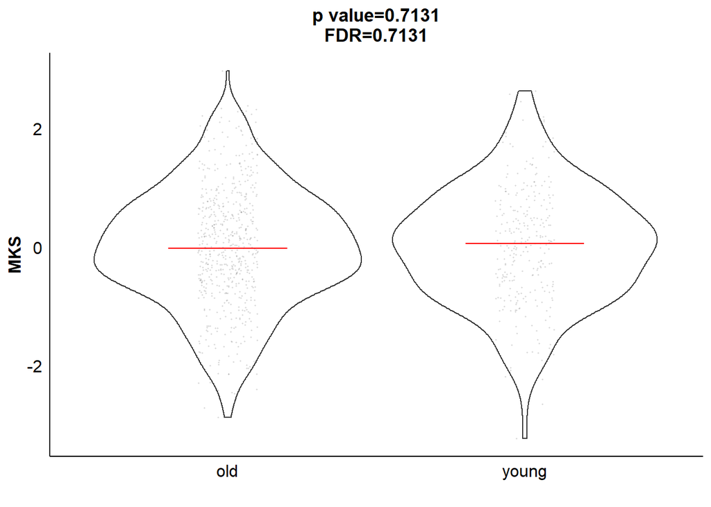

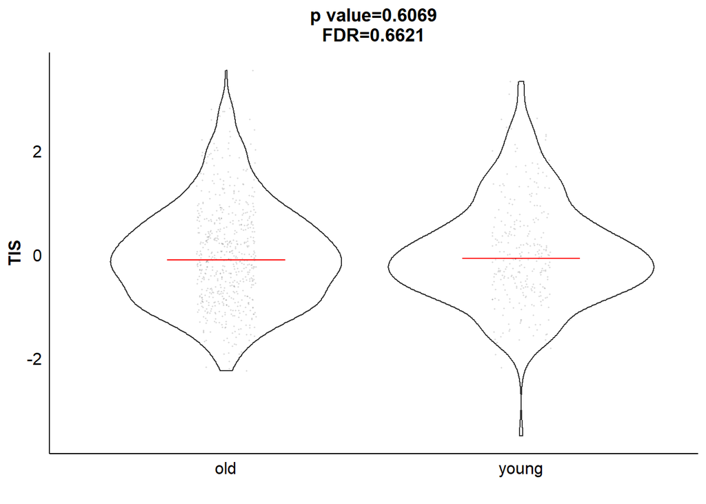

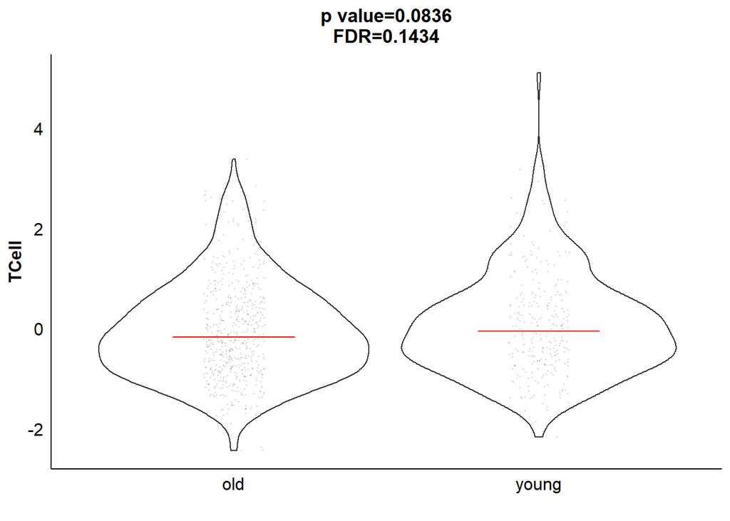

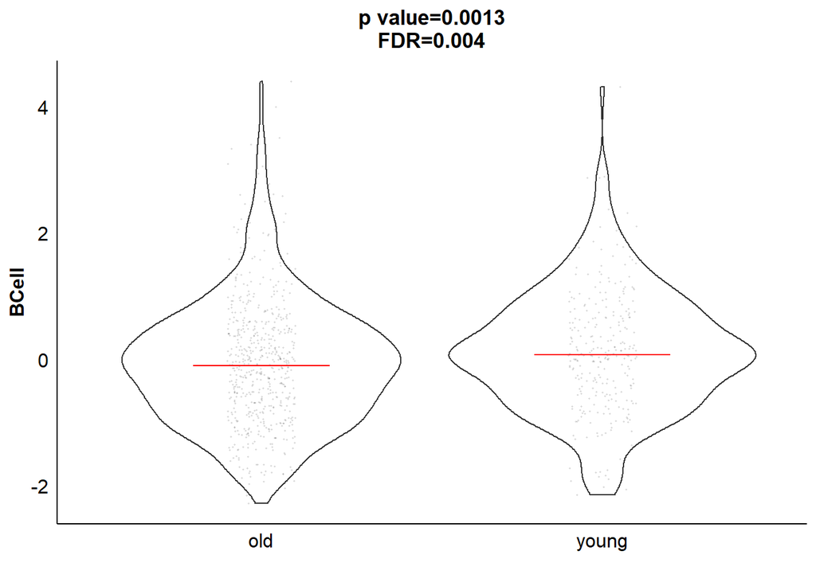

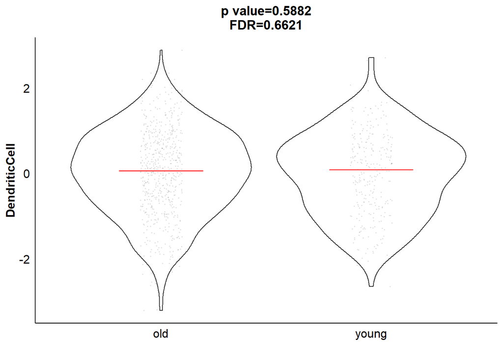

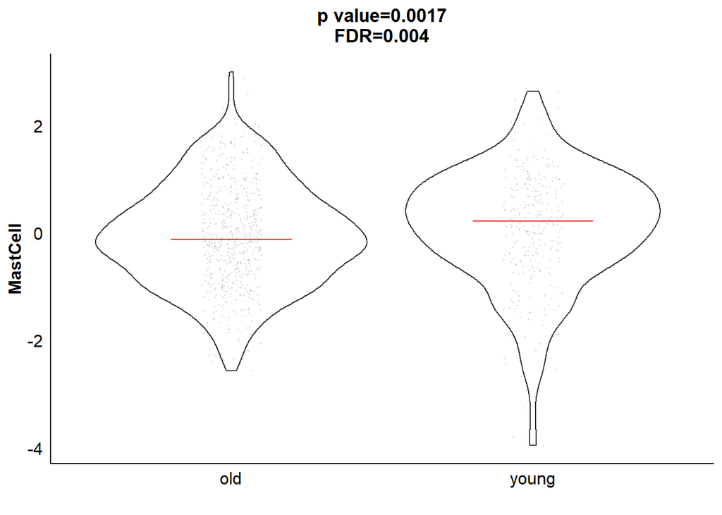

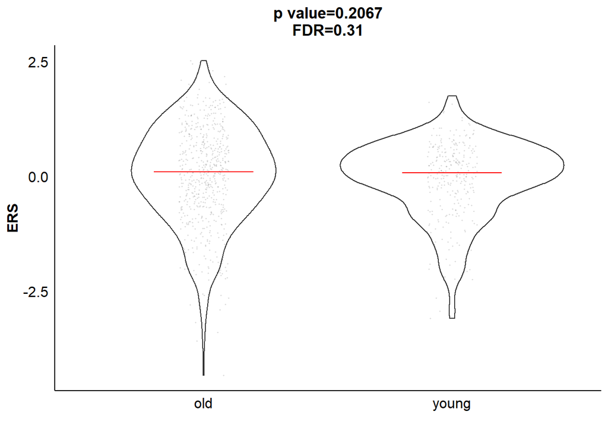

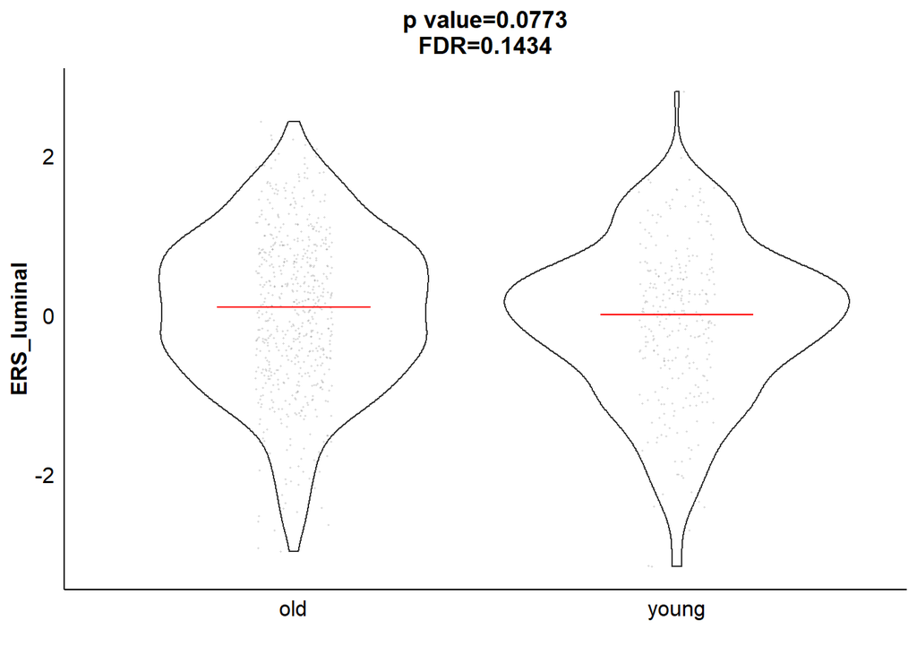

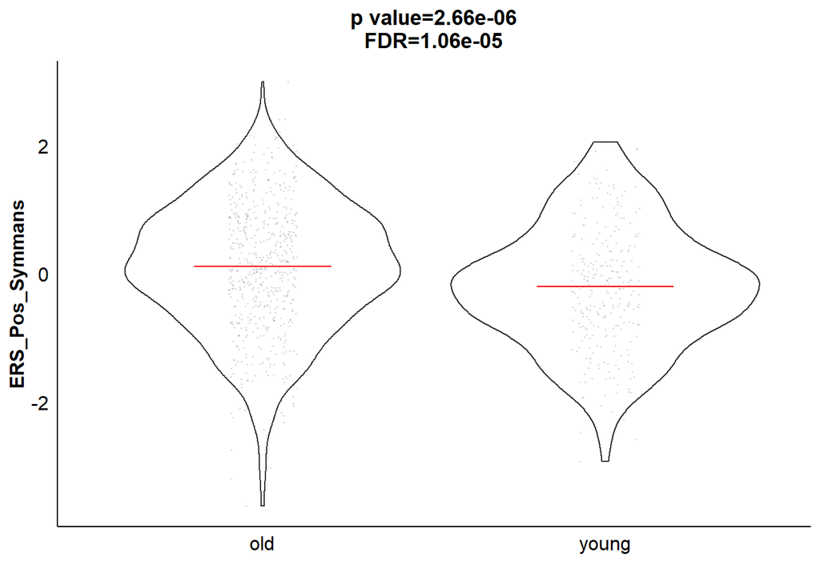

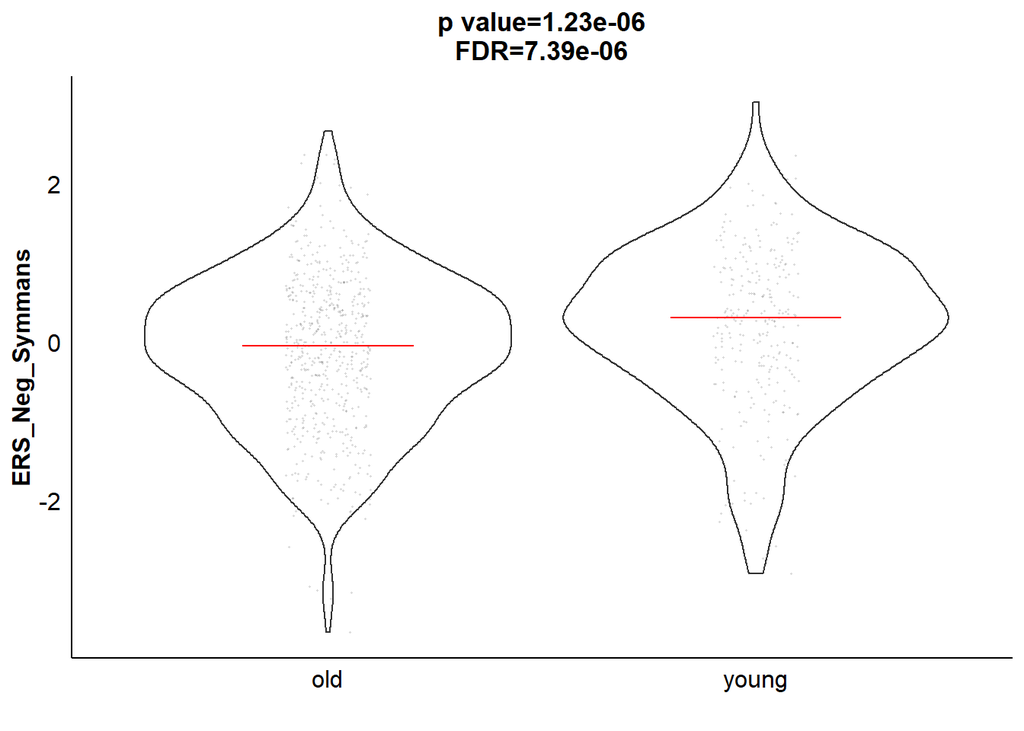

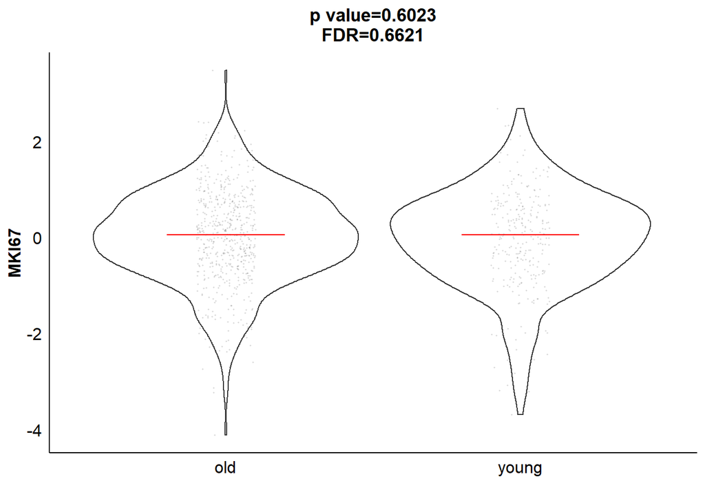

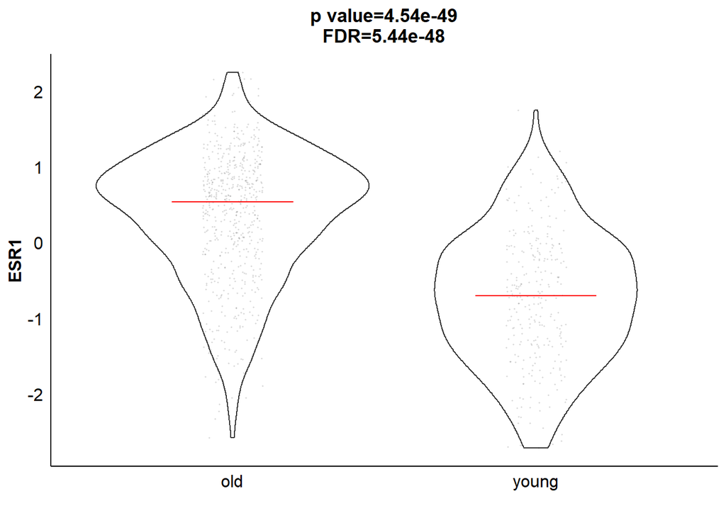

```r
for(s in rownames(mat_signature)){
  submat=finalMat[,c("type",s)]
  colnames(submat)[2]="Signature"
  med <- submat %>%
    group_by(type) %>%
    filter(!is.na(type)) %>%
    summarize(med = median(as.numeric(as.matrix(Signature))))

  if(ttMW$Pvalue[ttMW$Signature==s]<0.0001){
    pvalue<-formatC(ttMW$Pvalue[ttMW$Signature==s], format = "e", digits = 2)
  }else{
    pvalue=round(ttMW$Pvalue[ttMW$Signature==s],digits=4)
  }

  if(ttMW$FDR[ttMW$Signature==s]<0.0001){
    FDR<-formatC(ttMW$FDR[ttMW$Signature==s], format = "e", digits = 2)
  }else{
    FDR=round(ttMW$FDR[ttMW$Signature==s],digits=4)
  }

  p=ggplot(submat,
           aes(x=type,y=as.numeric(as.matrix(Signature)))) +
    geom_violin() +
    geom_jitter(alpha=.1,width = .1,size=.2)+th+ggtitle(paste0("p value=",pvalue,"\nFDR=",FDR))+xlab("")+ylab(s)+
    geom_segment(data = med,
                 aes(y=med,yend=med,x=as.numeric(type)-.2,
                     xend=as.numeric(type)+.2),color="red")
plot(p)
}
```

## COHORT-A Limma analysis for identifying differentially expressed genes (Fig.2b, Supp.Tab.S2)

Load required packages:

```r
library(limma)
# The following block is for Affy probeset annotations
options(connectionObserver = NULL) # temporary solution of  bug in the communication between the latest release of the RSQLite package and RStudio
library(hgu133a.db)
library(annotate)
```

Perform limma analysis for young vs old with Affymetrix source dataset as batch covariate:

```r
type <- clin$type
batch <- factor(clin$datas_new09...TransBIG.40.)
# Construct model matrix including both  batch and type
X <- model.matrix(~batch+type)
# Use limma to fit gene expression in mat to model matrix
fit <- lmFit(mat,X)
# Add Gene Symbols
fit$genes$probeset <- row.names(fit)
fit$genes$Symbol <- getSYMBOL(fit$genes$probeset,"hgu133a.db")
# Empirical Bayes Statistics for Differential Expression
fit <- eBayes(fit)
results <- decideTests(fit)
summary(results)
```

```
##        (Intercept) batch2 batch3 batch4 batch6 batch12 batch16 batch17 batch20
## Down             0   4073   5336   3012   4482    3779    7091    2196    2281
## NotSig           0  12959   6848  14824  10544    9965   10481    5546   15931
## Up           22283   5251  10099   4447   7257    8539    4711   14541    4071
##        batch21 batch25 batch33 batch40 typeyoung
## Down      4986    2348    1275    7186      1281
## NotSig    8876   17803   20289   10647     19089
## Up        8421    2132     719    4450      1913
```

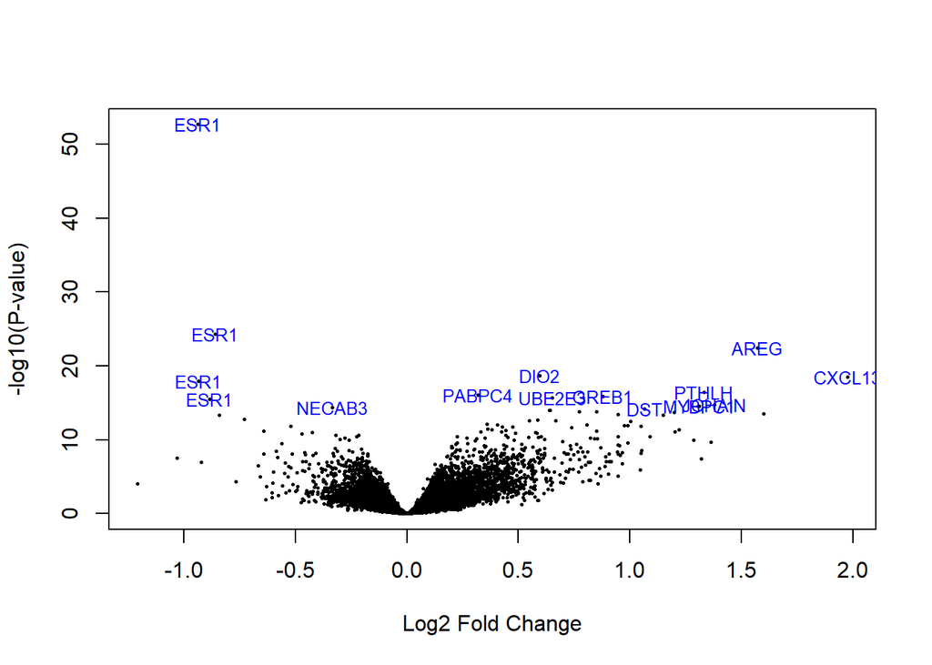

```r
volcanoplot(fit, coef="typeyoung", highlight = 15, names=fit$genes$Symbol)
```

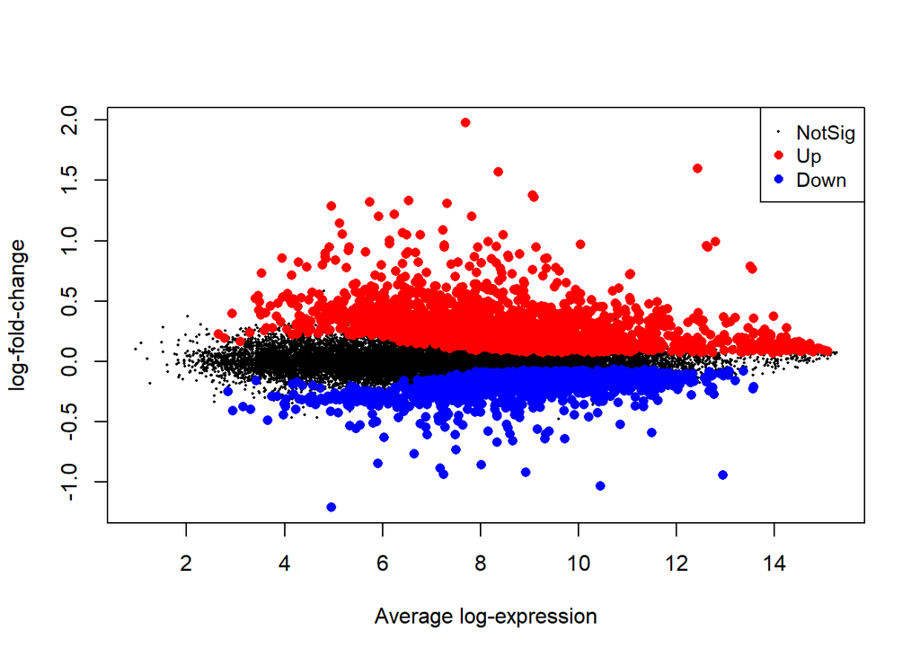

```r
plotMD(fit, coef="typeyoung", status=results)
```

```r
nSigGenes <- summary(results)[1,14]  + summary(results)[3,14]
deg.cohortA <- topTable(fit, coef = "typeyoung", n=nSigGenes)
# filter   FC ≥ 1.50 or ≤0.67
deg.cohortA.fil <- deg.cohortA[ (2^(deg.cohortA$logFC)>=1.5) | (2^(deg.cohortA$logFC)<=1/1.5) ,]
deg.cohortA.fil
```

|  | ID.probeset | ID.Symbol | logFC | AveExpr | t | P.Value | adj.P.Val | B |
| --- | --- | --- | --- | --- | --- | --- | --- | --- |
| 205225_at | 205225_at | ESR1 | -0.9393607 | 12.949039 | -16.521571 | 2.022761e-53 | 4.507317e-49 | 108.6371651 |
| 215552_s_at | 215552_s_at | ESR1 | -0.8589743 | 8.011444 | -10.663609 | 5.192038e-25 | 5.784709e-21 | 45.5498911 |
| 205239_at | 205239_at | AREG | 1.5718356 | 8.367768 | 10.203535 | 3.810980e-23 | 2.830669e-19 | 41.4110531 |
| 203700_s_at | 203700_s_at | DIO2 | 0.5943884 | 8.143718 | 9.219396 | 2.275820e-19 | 1.267802e-15 | 33.0419489 |
| 205242_at | 205242_at | CXCL13 | 1.9756929 | 7.694723 | 9.189796 | 2.924345e-19 | 1.303264e-15 | 32.8008106 |
| 211235_s_at | 211235_s_at | ESR1 | -0.9343335 | 7.243870 | -9.021017 | 1.206626e-18 | 4.481206e-15 | 31.4379478 |
| 211756_at | 211756_at | PTHLH | 1.3307822 | 6.529574 | 8.595069 | 3.926511e-17 | 1.249920e-13 | 28.0913814 |
| 205862_at | 205862_at | GREB1 | 0.8771889 | 8.557248 | 8.437489 | 1.375387e-16 | 3.405306e-13 | 26.8875720 |
| 210024_s_at | 210024_s_at | UBE2E3 | 0.6510623 | 9.576165 | 8.371697 | 2.308267e-16 | 5.143511e-13 | 26.3905055 |
| 211234_x_at | 211234_x_at | ESR1 | -0.8855841 | 7.173320 | -8.329161 | 3.220260e-16 | 6.523368e-13 | 26.0708956 |

[output cut: 137 more lines]

## Heatmap of common differentially expressed genes in younger versus older cases (Suppl.Fig.5, Cohort-A)

Import list of differentially expressed genes common between TCGA-cohort, Affy-Cohort-A, and Affy-Cohort-B.

```r
comm39.genes <- read.delim(paste0(datapath,"Common39Genes-probesets.txt"),h=T)
comm39.genes <- comm39.genes[order(comm39.genes$probeset),] # order by probeset
comm.genes.up <- comm39.genes[comm39.genes$Young=="Up",]
comm.genes.down <- comm39.genes[comm39.genes$Young=="Down",]
```

Combine a plot-matrix with genes in rows and samples in columns:

```r
plotMat <- mat[rownames(mat) %in% comm39.genes$probeset,]
stopifnot(rownames(plotMat)==comm39.genes$probeset)
rownames(plotMat) <- comm39.genes$Gene # add gene names to matrix

type <- clin$type  #type is a character array of age group
plotMat <- plotMat[,order(clin$age)] # reorder columns by patients age
type <- type[order(clin$age)]  # reorder columns by patients age

# scale each gene
plotMat <- t(scale(t(plotMat)))
```

Plot matrix as heatmap:

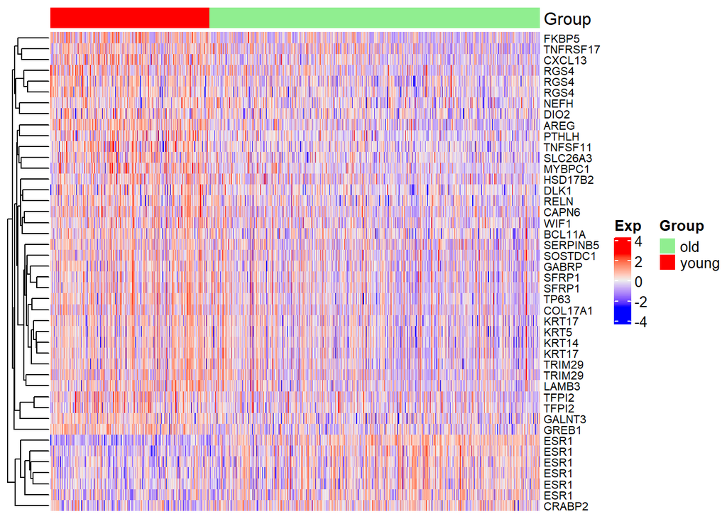

```r
require("ComplexHeatmap")
comm.heatmap=Heatmap(as.matrix(plotMat),name = "Exp",
                  top_annotation = HeatmapAnnotation(Group=type,col=list(Group=c("old"="lightgreen","young"="red"))),
                  show_row_names=TRUE,
                  row_names_gp = gpar(fontsize = 8),
                  show_column_names = FALSE,
                  cluster_columns = FALSE
)
plot(comm.heatmap)
```

# **COHORT-B**

## Re-do analyses with Cohort-B

## SELECT “COHORT B” of breast cancer datasets with comparability metric >=5000

```r
# Select a subset of comparab by defining criteria:
compar.subset= subset(comparab, subset= sum.squ.nrm.diff >= 5000)
# vector of corresponding datasets:
datas.subset=compar.subset$dataset
# generate logical vector FALSE/TRUE for the complete dataset of 2007 BC:
subset.index.vector=(tdsn %in% datas.subset)
# query selected samples from transposed chipdata matrix and t.header:
tcdm.valid=tcdm[subset.index.vector , ]
t.header.valid= t.header[subset.index.vector,]
# remove temporary variables:
rm(compar.subset, datas.subset, subset.index.vector)
```

## Determine RecurrenceScore for Cohort B

We apply the oncotypedx function from the genefu package on the validation cohort of 837 samples:

```r
library(genefu)
rs.valid <- oncotypedx(data= tcdm.valid, annot= U133A_Affy_Entrez, do.mapping=FALSE, verbose=TRUE)
t.header.valid <- cbind(t.header.valid,rs.valid$score)
```

Exclude those 20% of samples with highest oncotypedx scoring:

```r
t.header.valid.lowint <- subset(t.header.valid, subset= rs.valid$score < as.numeric(quantile(rs.valid$score, probs=0.8)))
tcdm.valid.lowint <- tcdm.valid[rownames(tcdm.valid) %in% rownames(t.header.valid.lowint),]
dim(tcdm.valid.lowint)
```

```
## [1]   669 22283
```

## COHORT-B Compare expression signatures between young and old patients

A label “cohort” is defined which can be used to tag output files

```r
cohort <- "Cohort-B_"
```

Log2-expression data matrix ==> mat; Clinical data ==> clin

```r
clin <- t.header.valid.lowint
clin$Xcombi_id <- rownames(clin)
mat <- log2(t(tcdm.valid.lowint))
```

**Here we repeat for Cohort-B the analysis performed above (on Cohort-A):**

## Distribution of ESR1 and MKI67 mRNA expression in ER+/HER2- breast cancers in three cohorts. (Suppl.Fig.1, Cohort-B)

Define three age groups and plot data:

```r
clin$type <- "intermediate"
clin$type[clin$age>=55] <- "old"
clin$type[clin$age<=50] <- "young"
clin$type <- factor(clin$type, levels = c("young", "intermediate", "old"))
plotdat <- data.frame(mat["205225_at",], clin$type)
colnames(plotdat) <- c("ESR1_205225_at", "Age_group")
plotdat$MKI67_mean <- apply(mat[which(rownames(mat)%in%sig_lists$MKI67),],2,mean)
```

Plot distribution of ESR1 expression according to age group:

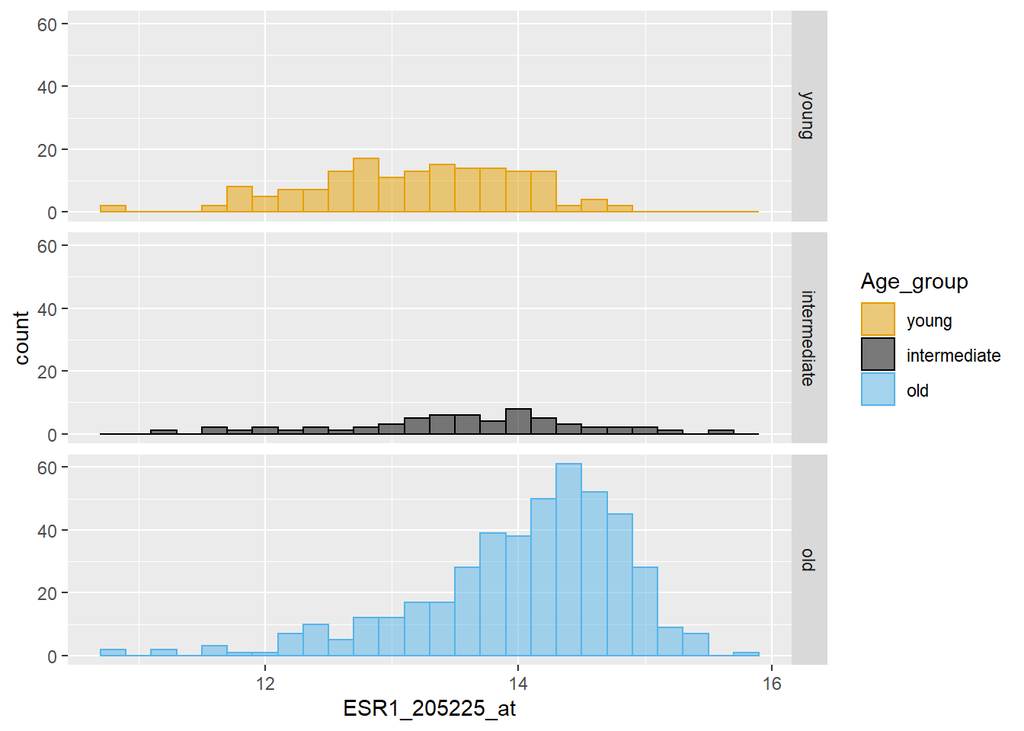

```r
p <- ggplot(plotdat, aes(x = ESR1_205225_at, fill = Age_group, color = Age_group)) +
  geom_histogram(binwidth=0.2,  alpha=0.5, position="identity")
plot(p + scale_color_manual(values=c("#E69F00", "black", "#56B4E9"))+
  scale_fill_manual(values=c("#E69F00", "black", "#56B4E9"))+
  facet_grid(Age_group ~ .))
```

Plot distribution of MKI67 expression according to age group:

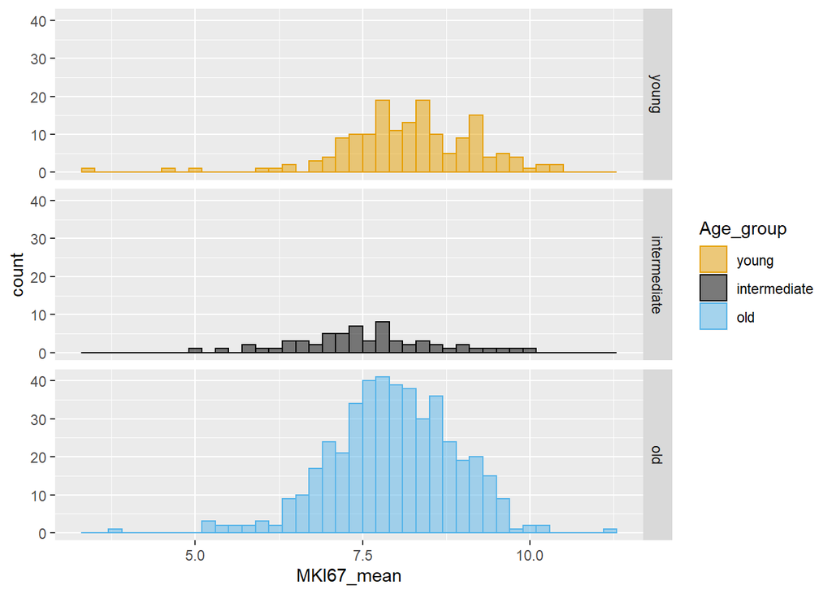

```r
p <- ggplot(plotdat, aes(x = MKI67_mean, fill = Age_group, color = Age_group)) +
  geom_histogram(binwidth=0.2,  alpha=0.5, position="identity")
plot(p + scale_color_manual(values=c("#E69F00", "black", "#56B4E9"))+
  scale_fill_manual(values=c("#E69F00", "black", "#56B4E9"))+
  facet_grid(Age_group ~ .))
```

## Compare young (<=50yr) vs. old (>=55) in Cohort-B:

Select sample subgroups (>=55 yr vs. <=50 yr):

```r
### Generate "type" as factor age>=55:old or age<=50:young
clin$type <- NA
clin$type[clin$age>=55] <- "old"
clin$type[clin$age<=50] <- "young"
clin$type <- as.factor(clin$type)

### EXCLUDE SAMPLES with age between 51 and 54 years  (clin$type=NA)
clin <- clin[!is.na(clin$type),]
mat <- mat[,colnames(mat) %in% rownames(clin)]
```

Estimate the expression signatures by taking the average expression of all member genes in a signature for each individual patient.

```r
mat_signature=NULL
for(sig in names(sig_lists)){
  score=apply(mat[which(rownames(mat)%in%sig_lists[[sig]]),],2,mean)
  mat_signature=rbind(mat_signature,score)
}
rownames(mat_signature)=names(sig_lists)
# Add ESR1 as single gene to the mat_signature
ESR1 <- mat["205225_at",]
mat_signature <- rbind(mat_signature, ESR1)
mat_signature_zscore=as.data.frame(cbind(Xcombi_id=colnames(mat_signature),apply(mat_signature,1,function(x)(x-mean(x))/sd(x))))
finalMat=merge(clin, mat_signature_zscore, by="Xcombi_id")
```

### Scatter plots for correlation between signatures in Suppl.Fig.4, Cohort-B:

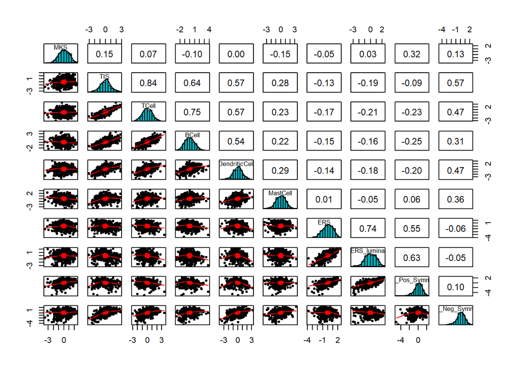

```r
library(psych)
pairs.panels(finalMat%>%dplyr::select("MKS","TIS","TCell","BCell","DendriticCell","MastCell","ERS","ERS_luminal","ERS_Pos_Symmans","ERS_Neg_Symmans")%>%mutate_all(~as.numeric(as.matrix(.))),
             method = "pearson", # correlation method
             hist.col = "#00AFBB",
             density = TRUE,  # show density plots
             ellipses = TRUE, # show correlation ellipses
             cex=1
)
```

### Comparison of signatures in young vs old by Mann-Whitney test (Table 2, Cohort-B)

```r
ttMW=NULL
for(s in rownames(mat_signature)){
  submat=finalMat[,c("type",s)]
  submat[,s]=as.numeric(as.matrix(submat[,s]))

  pvalue=wilcox.test(submat[submat$type=="young",s],submat[submat$type=="old",s])$p.value
  tmpmean=tapply(submat[,s],submat$type,mean)
  ttMW=rbind(ttMW,cbind(Signature=s,'log2 Fold Change'=as.numeric(tmpmean["young"])-as.numeric(tmpmean["old"]),'Mean in Young'=tmpmean["young"],'Mean in Old'=tmpmean["old"],Pvalue=pvalue))
}

ttMW=as.data.frame(ttMW)
ttMW$Pvalue=as.numeric(as.matrix(ttMW$Pvalue))
ttMW$FDR=p.adjust(ttMW$Pvalue,method="fdr")

ttMW$`log2 Fold Change`=as.numeric(as.matrix(ttMW$`log2 Fold Change`))
ttMW$`Mean in Young`=as.numeric(as.matrix(ttMW$`Mean in Young`))
ttMW$`Mean in Old`=as.numeric(as.matrix(ttMW$`Mean in Old`))

ttMW
```

|  | Signature | log2 Fold Change | Mean in Young | Mean in Old | Pvalue | FDR |
| --- | --- | --- | --- | --- | --- | --- |
| young | MKS | -0.005737229 | -0.004211070 | 0.001526159 | 8.833521e-01 | 9.495059e-01 |
| young.1 | TIS | 0.203587945 | 0.149431545 | -0.054156399 | 1.760321e-02 | 3.017693e-02 |
| young.2 | TCell | 0.410577061 | 0.301359518 | -0.109217543 | 1.408845e-05 | 5.635380e-05 |
| young.3 | BCell | 0.513042291 | 0.376567987 | -0.136474304 | 3.361948e-08 | 2.017169e-07 |
| young.4 | DendriticCell | 0.142518553 | 0.104607214 | -0.037911339 | 2.459361e-02 | 3.689041e-02 |
| young.5 | MastCell | 0.008683742 | 0.006373781 | -0.002309961 | 7.306503e-01 | 8.767804e-01 |
| young.6 | ERS | -0.100551178 | -0.073803574 | 0.026747604 | 1.856299e-01 | 2.475066e-01 |
| young.7 | ERS_luminal | 0.013026235 | 0.009561128 | -0.003465107 | 9.495059e-01 | 9.495059e-01 |
| young.8 | ERS_Pos_Symmans | -0.222489779 | -0.163305306 | 0.059184473 | 2.382453e-03 | 4.764907e-03 |
| young.9 | ERS_Neg_Symmans | 0.272456987 | 0.199980744 | -0.072476243 | 5.856485e-04 | 1.756946e-03 |

[output cut: 2 more lines]